# mpQTL Workshop on SNP array intensities and SNP dosage probabilities

```r
library(mpQTL)
```

# Introduction

`mpQTL` is an R package for single marker association analysis in structured populations of any ploidy (e.g. multiparental populations, GWAS panels or a combination of them). Input genotypic data can be both biallelic (continuous or discrete SNP data) or multiallelic (haplotypes). The present vignette will show how to use `mpQTL` to run a QTL analysis using continuous SNP data, such as SNP array intensities or SNP dosage probabilities.

# Load example data

```r
# Load  example data ------------------------
load("workshop_data.RData")

# it contains
head(mrksel)
```

```
#> [1] "mrk052922" "mrk087015" "mrk105146" "mrk084843" "mrk041352" "mrk098634"
```

```r
head(indsel)
```

```
#> [1] "ind001" "ind002" "ind003" "ind004" "ind005" "ind006"
```

```r
head(map)
```

```
#>           marker chromosome position
#> 38905  mrk030876          0 1.000000
#> 38906  mrk030875          0 1.001034
#> 132508 mrk122446          0 1.002068
#> 132509 mrk122447          0 1.003102
#> 23599  mrk017354          0 1.004136
#> 23600  mrk017353          0 1.005170
```

```r
head(phenotypes)
```

```
#>        pheno01
#> ind439   140.1
#> ind440   127.5
#> ind441    14.0
#> ind442    82.4
#> ind443   120.9
#> ind444     7.7
```

# Chunkwise data import by 'ff'

In our pipeline, array intensity ratios and dosage probabilities can be found in one of the output of `fitPoly`. However, those files are often very big, so that loading them on the computer RAM might be impracticable. Here, we included a tip to overcome this issue, using chunkwise operations provided by the `ff` package. Please, see the `ff` manual (in the workshop folder) for a detailed explanation. A useful feature of `ff` is the possibility to subset data, while importing it chunckwise. In fact, part of the dataset might be redundant or unnecessary (e.g. one could need a subset of individuals only or a subset of well performing markers).

```r
# Chunkwise data import by 'ff' -----------------------------
library("ff")
library("ffbase")

## preview
readLines("scores.dat", 10)

scores_preview <- read.delim.ffdf(file="scores.dat",
                                  nrows = 10)
scores_preview
```

```r
## import data and subset based on marker names (or sample names)
names_ffdf <- read.delim.ffdf(file="scores.dat",
                                     transFUN = function(x, n = mrksel, m = indsel) {
                                       idx <- x[,2] %in% n & x[,3] %in% m
                                       x[idx, 1:3]
                                     })
names_ffdf
rownames(names_ffdf) <- NULL

data_ffdf <- read.delim.ffdf(file="scores.dat",
                             transFUN = function(x, n = mrksel, m = indsel){
                               idx <- x[,2] %in% n & x[,3] %in% m
                               x[idx, c(4:9,12)]
                             })
data_ffdf
rownames(data_ffdf) <- NULL

data_ffmat <- ffbase:::as.ff_matrix.ffdf(data_ffdf)
data_ffmat
```

If the dataset has been reduced enough in size, it is possible to load it on RAM (i.e. convert the ff object into the correspondent RAM object). To do that, use the square brackets (e.g. data_ffmat[]). Make sure that row names are not inherited by the ff object (using ramattribs), since they can occupy memory.

```r
## get the RAM object
ramattribs(data_ffmat[1:10,])
```

```r
data <- data_ffmat[]
data[1:5,]
```

```
#>          ratio           P0           P1           P2           P3           P4
#> [1,] 0.1585962 9.999889e-01 1.113655e-05 7.055158e-14 1.328269e-24 1.331346e-38
#> [2,] 0.1892244 9.998744e-01 1.255962e-04 5.429653e-12 5.809005e-22 3.350396e-35
#> [3,] 0.5800312 6.983903e-09 5.770866e-02 9.365612e-01 5.730106e-03 2.149658e-08
#> [4,] 0.2721451 9.553823e-01 4.461751e-02 2.101521e-07 1.566518e-15 6.490628e-27
#> [5,] 0.1644890 9.999820e-01 1.799210e-05 1.667112e-13 4.427241e-24 6.274863e-38
#>      geno
#> [1,]    0
#> [2,]    0
#> [3,]   NA
#> [4,]    0
#> [5,]    0
```

```r
names <- names_ffdf[]
head(names)
```

```
#>   marker MarkerName SampleName
#> 1     25  mrk000020     ind001
#> 2     25  mrk000020     ind002
#> 3     25  mrk000020     ind003
#> 4     25  mrk000020     ind004
#> 5     25  mrk000020     ind005
#> 6     25  mrk000020     ind006
```

Now, we can remove ff objects and clear reference to flat files. Optionally, it is possible to save the ff flat files to access them in a later stage.

```r
# ## save and load
# ffsave(data_ffmat, file=""vignettes/workshop_20201203/ff_files/data_ffmat")
# ffload("vignettes/workshop_20201203/ff_files/data_ffmat")

## delete ff files
delete(names_ffdf, data_ffdf, data_ffmat, scores_preview)
```

```
#> [1] TRUE
```

```r
rm(names_ffdf, data_ffdf, data_ffmat, scores_preview)
gc()
```

```
#>            used  (Mb) gc trigger  (Mb) max used  (Mb)
#> Ncells   970197  51.9    3418131 182.6  2024837 108.2
#> Vcells 21675050 165.4   35089937 267.8 29172020 222.6
```

```r
detach("package:ffbase", unload=TRUE)
detach("package:ff", unload=TRUE)
```

```
#> Detaching package ff
#> Unloading package ff
```

```r
detach("package:bit", unload=TRUE)
```

# Transform and reshape data

SNP array intensity ratios $Y/(X+Y)$ are already available in the output of fitPoly. We just need to reshape them into a matrix, with markers in rows and individuals in column (better to add marker names and individual names).

```r
# Transform and reshape data ---------------------------
# + reshape ratios -------------------
ratios <- matrix(data[,1], nrow = length(unique(names$MarkerName)), byrow = T)
dim(ratios)
```

```
#> [1] 10000    99
```

```r
ratios <- round(ratios,4)

rownames(ratios) <- unique(names$MarkerName)
colnames(ratios) <- unique(names$SampleName)
```

```r
ratios[1:5,1:5]
```

```
#>           ind001 ind002 ind003 ind004 ind005
#> mrk000020 0.1586 0.1892 0.5800 0.2721 0.1645
#> mrk000080 0.6333 0.6236 0.6509 0.6329 0.5833
#> mrk000115 0.2562 0.2369 0.2092 0.2849 0.2695
#> mrk000119 0.3268 0.1280 0.3098 0.3440 0.1054
#> mrk000139 0.6128 0.5540 0.6380 0.5902 0.5558
```

Dosage probabilities need to be transformed in a format that can be accepted by mpQTL. The simplest way is to calculate a weighted mean of the dosage probabilities, where the weigth of each probability is the corresponding dosage. Then, all is normalized to 1, so that the final variable will range between 0 and 1 (same as for the intensity ratios).

```r
# + dosage probabilities ------------------
Bfreq <- dosP2Bfreq(data[,2:6])
dim(Bfreq)
Bfreq[1:9]

attributes(Bfreq)
class(Bfreq)
typeof(Bfreq)
Bfreq <- round(Bfreq,4)

Bfreq <- matrix(Bfreq, nrow = length(unique(names$MarkerName)), byrow = T)
dim(Bfreq)
Bfreq[1:5,1:5]

rownames(Bfreq) <- unique(names$MarkerName)
colnames(Bfreq) <- unique(names$SampleName)
```

```r
Bfreq[1:5,1:5]
```

```
#>           ind001 ind002 ind003 ind004 ind005
#> mrk000020 0.0000 0.0000 0.4870 0.0112 0.0000
#> mrk000080 0.5000 0.5000 0.5000 0.5000 0.5000
#> mrk000115 0.0001 0.0000 0.0000 0.0036 0.0004
#> mrk000119 0.3039 0.0000 0.2674 0.3759 0.0000
#> mrk000139 0.6514 0.4661 0.7189 0.5777 0.4714
```

```r
range(c(Bfreq))
```

```
#> [1] 0 1
```

Please, notice that filtration steps are not included in `mpQTL`. Running those screenings might result in missing genotypes (unrelible genotypes are set to NA). Here, we randomly include some missing values to illustrate how the next functions will handle them.

```r
# Simulate filtration steps ----------------------------
set.seed(3)
naidx <- sample(1:length(ratios), 100)
ratios[naidx] <- NA
Bfreq[naidx] <- NA
```

# Kinship calculation and genotype imputation

For all the `mpQTL` functions used in the next steps, you can also refer to the main `mpQTL` vignette (distributed last December) for more details. A kinship matrix between individuals can be automatically calculated running the main `mpQTL` function `map.QTL`. However, especially when working on big datasets, it can be convenient to calculate the kinship matrix in advance (and only once) and provide it to `map.QTL`. This can save time and ensure consistency in your analyses. The same is valid for imputaion of missing genotypes. Therefore, in this vignette these two steps will be run before the actual association analysis.

## Kinship

```r
# Kinship calculation and genotype imputation ------------------
## + Kinship matrix -----------
## Used for knn imputation or structure correction.
## To calculate a kinship using a subset of markers see sample.cM
Kr <- calc.K(t(ratios))
Kr[1:5,1:5]
```

```
#>              ind001      ind002      ind003       ind004      ind005
#> ind001  0.929236211  0.10336043 -0.02264225 -0.002404543 -0.10635415
#> ind002  0.103360430  0.84132459 -0.06217076 -0.097751670 -0.14975962
#> ind003 -0.022642250 -0.06217076  1.13533193  0.099784724 -0.09728868
#> ind004 -0.002404543 -0.09775167  0.09978472  0.949145882 -0.01411746
#> ind005 -0.106354147 -0.14975962 -0.09728868 -0.014117460  0.97368014
```

```r
Kp <- calc.K(t(Bfreq))
Kp[1:5,1:5]
```

```
#>              ind001      ind002      ind003       ind004       ind005
#> ind001  0.926992404  0.09881211 -0.02393476  0.004516685 -0.096316111
#> ind002  0.098812114  0.78682910 -0.05083425 -0.087134454 -0.143433328
#> ind003 -0.023934758 -0.05083425  1.08164938  0.080322945 -0.088655450
#> ind004  0.004516685 -0.08713445  0.08032294  0.967260091 -0.001750643
#> ind005 -0.096316111 -0.14343333 -0.08865545 -0.001750643  0.947480127
```

```r
## visualize kinship
# pcoa.plot(Kr)
```

## Genotypes imputation

Missing genotypes can be imputed using `impute.knn`. When continuos data (such as intensity ratios and dosage probabilities) are provided, `impute.knn` will return the genotype mean of the n most similar kneighbors.

```r
## + geno imputation --------------------
## Since we provide K, map is not needed
sum(is.na(ratios))
```

```
#> [1] 100
```

```r
ratios2 <- impute.knn(ratios,
                      ploidy = 4,
                      kneighbors = 20,
                      K=Kr)
```

```
#> Imputation will be performed on continuous genotypes.
```

```r
ratios2[1:5,1:5]
```

```
#>           ind001 ind002 ind003 ind004 ind005
#> mrk000020 0.1586 0.1892 0.5800 0.2721 0.1645
#> mrk000080 0.6333 0.6236 0.6509 0.6329 0.5833
#> mrk000115 0.2562 0.2369 0.2092 0.2849 0.2695
#> mrk000119 0.3268 0.1280 0.3098 0.3440 0.1054
#> mrk000139 0.6128 0.5540 0.6380 0.5902 0.5558
```

```r
sum(is.na(Bfreq))
```

```
#> [1] 100
```

```r
Bfreq2 <- impute.knn(Bfreq,
                     ploidy = 4,
                     kneighbors = 20,
                     K=Kp)
```

```
#> Imputation will be performed on continuous genotypes.
```

# Run association models

## Input matrices order

Association models can be run by `map.QTL`. This function assumes that all the input matrices (or vectors) provided by the user consistently refer to the same markers (in the same order) and the same individuals (in the same order). The function `inputOrder` can be used (if marker names and individual names are specified), to make sure this requirement is met.

```r
# Run association models --------------------------------
# + Input matrices order -------------------
ordInp_ratios <- inputOrder(ratios2, pheno = phenotypes, map = map, K = Kr)
```

```
#> 99 genotyped and phenotyped individuals will be used
```

```r
str(ordInp_ratios)
```

```
#> List of 6
#>  $ geno    : num [1:10000, 1:99] 0.3004 0.6209 0.4716 0.0933 0.2522 ...
#>   ..- attr(*, "dimnames")=List of 2
#>   .. ..$ : chr [1:10000] "mrk045372" "mrk016895" "mrk048042" "mrk098687" ...
#>   .. ..$ : chr [1:99] "ind439" "ind440" "ind441" "ind442" ...
#>  $ pheno   :'data.frame':    99 obs. of  1 variable:
#>   ..$ pheno01: num [1:99] 140.1 127.5 14 82.4 120.9 ...
#>  $ map     :'data.frame':    10000 obs. of  3 variables:
#>   ..$ marker    : chr [1:10000] "mrk045372" "mrk016895" "mrk048042" "mrk098687" ...
#>   ..$ chromosome: num [1:10000] 0 0 0 0 0 0 0 0 0 0 ...
#>   ..$ position  : num [1:10000] 0 0.378 0.756 1.028 1.056 ...
#>  $ cofactor: NULL
#>  $ Q       : NULL
#>  $ K       : num [1:99, 1:99] 0.9053 -0.0514 0.0533 0.1903 0.3223 ...
#>   ..- attr(*, "dimnames")=List of 2
#>   .. ..$ : chr [1:99] "ind439" "ind440" "ind441" "ind442" ...
#>   .. ..$ : chr [1:99] "ind439" "ind440" "ind441" "ind442" ...
```

```r
ordInp_Bfreq <- inputOrder(Bfreq2, pheno = phenotypes, map = map, K = Kp)
```

```
#> 99 genotyped and phenotyped individuals will be used
```

## Li & Ji threshold

As an alternative to permutations, the method of Li & Ji can be used to a adjust significance for multiple testing.

```r
# + Li & Ji threshold --------------------
ratios_thr <- thr.LiJi(ordInp_ratios$geno,
                       chrom = ordInp_ratios$map$chromosome,
                       ploidy = 4)
```

```
#> Meff of chromosome 0 = 144
#> Meff of chromosome 1 = 129
#> Meff of chromosome 2 = 140
#> Meff of chromosome 3 = 119
#> Meff of chromosome 4 = 131
#> Meff of chromosome 5 = 133
#> Meff of chromosome 6 = 131
#> Meff of chromosome 7 = 136
```

```r
ratios_thr
```

```
#> $threshold
#> [1] 4.825217e-05
#>
#> $Meff
#> [1] 144 129 140 119 131 133 131 136
```

```r
Bfreq_thr <- thr.LiJi(ordInp_Bfreq$geno,
                       chrom = ordInp_Bfreq$map$chromosome,
                       ploidy = 4)
```

## Naive model and K model

Now, we run the association models using `map.QTL`.

```r
# + Naive model and K model -------------------------
## using ratios
ratios_naive <- map.QTL(phenotypes = ordInp_ratios$pheno,
                        genotypes = ordInp_ratios$geno,
                        ploidy = 4,
                        K = ordInp_ratios$K,
                        K_identity = T, #to force naive
                        # impute = F, #not needed, since we provided imputed genotypes
                        map = ordInp_ratios$map,
                        no_cores = 6)
```

```
#> Continuous SNP genotypes have been detected,
#> Square K matrix has been provided. Using as it is.
#> 0 % missing genotypes detected.
#> No imputation will be performed.
#> No Q matrix will be used.
#> Mixed model will be used.
#> Association completed.
```

```r
ratios_K <- map.QTL(phenotypes = ordInp_ratios$pheno,
                    genotypes = ordInp_ratios$geno,
                    ploidy = 4,
                    K = ordInp_ratios$K,
                    map = ordInp_ratios$map,
                    no_cores = 6)
```

```
#> Continuous SNP genotypes have been detected,
#> Square K matrix has been provided. Using as it is.
#> 0 % missing genotypes detected.
#> No imputation will be performed.
#> No Q matrix will be used.
#> Mixed model will be used.
#> Association completed.
```

```r
## using dosage probabilities
Bfreq_naive <- map.QTL(phenotypes = ordInp_Bfreq$pheno,
                        genotypes = ordInp_Bfreq$geno,
                        ploidy = 4,
                        K = ordInp_Bfreq$K,
                        K_identity = T, #to force naive
                        # impute = F, #not needed, since we provided imputed genotypes
                        map = ordInp_Bfreq$map,
                        no_cores = 6)

Bfreq_K <- map.QTL(phenotypes = ordInp_Bfreq$pheno,
                   genotypes = ordInp_Bfreq$geno,
                   ploidy = 4,
                   K = ordInp_Bfreq$K,
                   map = ordInp_Bfreq$map,
                   no_cores = 6)
```

## Manhattan plots

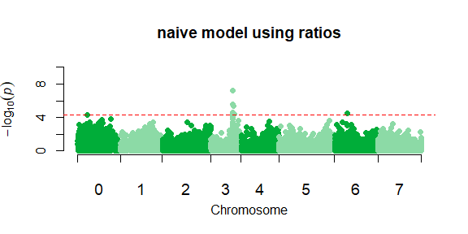

```r
# + Manhattan plots -------------------------
## plots for ratios
skyplot(-log10(ratios_naive$pheno01$pval),
        map = ordInp_ratios$map,
        chromspace = 0,
        threshold = -log10(ratios_thr$threshold),
        main="naive model using ratios")
```

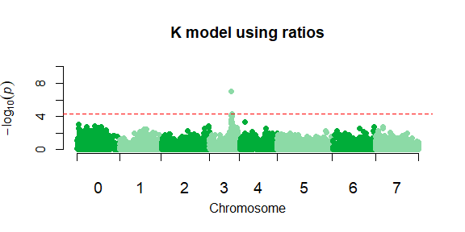

```r
skyplot(-log10(ratios_K$pheno01$pval),
        map = ordInp_ratios$map,
        chromspace = 0,
        threshold = -log10(ratios_thr$threshold),
        main="K model using ratios")
```

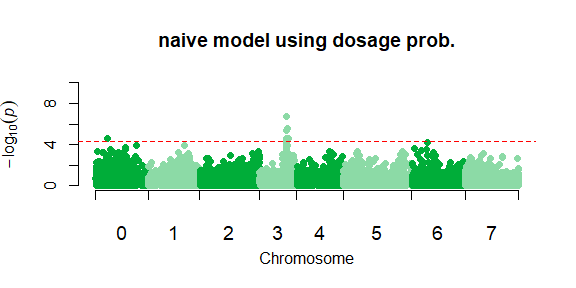

```r
## plots for dosage prob.
skyplot(-log10(Bfreq_naive$pheno01$pval),
        map = ordInp_Bfreq$map,
        chromspace = 0,
        threshold = -log10(Bfreq_thr$threshold),
        main="naive model using dosage prob.")
```

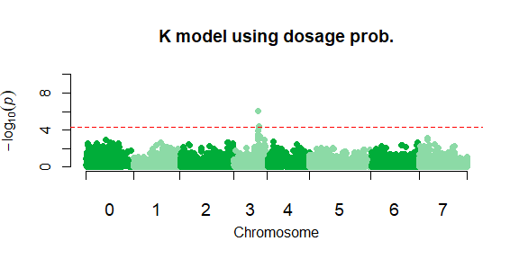

```r
skyplot(-log10(Bfreq_K$pheno01$pval),
        map = ordInp_Bfreq$map,
        chromspace = 0,
        threshold = -log10(Bfreq_thr$threshold),
        main="K model using dosage prob.")
```

## Genotype-phenotype plots

```r
# + Genotype-phenotype plots -----------------------------
## peak marker for ratios
ratios_K$pheno01$pval[which.max(-log10(ratios_K$pheno01$pval))]
```

```
#>    mrk050949
#> 1.049358e-07
```

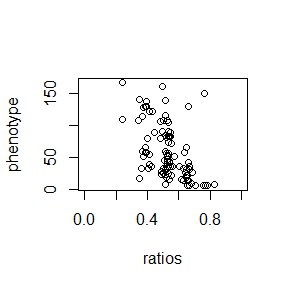

```r
plot(ordInp_ratios$geno["mrk050949",],
     ordInp_ratios$pheno[,1],
     xlim = c(0,1),
     xlab = "ratios",
     ylab = "phenotype")
```

```r
## peak marker for dosage prob.
Bfreq_K$pheno01$pval[which.max(-log10(Bfreq_K$pheno01$pval))]
```

```
#>    mrk050949
#> 9.082411e-07
```

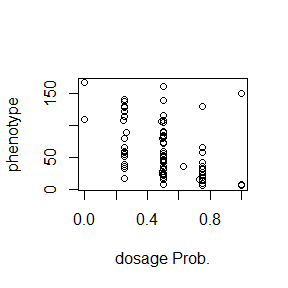

```r
plot(ordInp_Bfreq$geno["mrk050949",],
     ordInp_Bfreq$pheno[,1],
     xlim = c(0,1),
     xlab = "dosage Prob.",
     ylab = "phenotype")
```

# B allele frequency plots

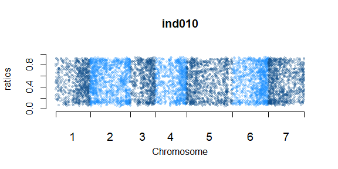

```r
# B allele frequency plots ---------------------------
library(scales)

ordMapRatio <- inputOrder(ratios[rownames(ratios) %in% map$marker[map$chromosome != 0],], map = map)
# colnames(ordMapRatio$geno)
# str(ordMapRatio)

skyplot(ordMapRatio$geno[,"ind010"],
        map = ordMapRatio$map, #[physmap$physical_chr!=0,]
        ylim = c(0,1.1),
        pch = 20,
        cex = 0.9,
        ylab = "ratios",
        col = alpha(c("dodgerblue4","dodgerblue"),0.2),
        chromspace = 0,
        main="ind010")
```

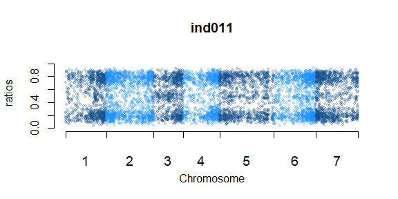

```r
skyplot(ordMapRatio$geno[,"ind011"],
        map = ordMapRatio$map, #[physmap$physical_chr!=0,]
        ylim = c(0,1.1),
        pch = 20,
        cex = 0.9,
        ylab = "ratios",
        col = alpha(c("dodgerblue4","dodgerblue"),0.2),
        chromspace = 0,
        main="ind011")
```

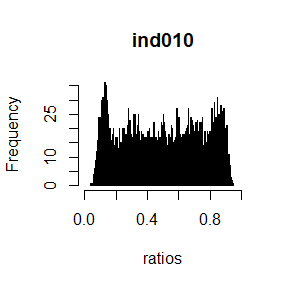

```r
hist(ordMapRatio$geno[,"ind010"],
     breaks = 500,
     xlim = c(0,1),
     main="ind010",
     xlab = "ratios")
```

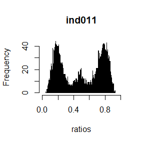

```r
hist(ordMapRatio$geno[,"ind011"],
     breaks = 500,
     xlim = c(0,1),
     main="ind011",
     xlab = "ratios")
```

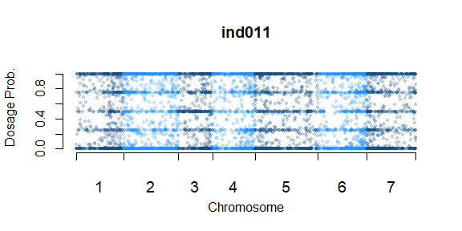

```r
ordMapBfreq <- inputOrder(Bfreq[rownames(Bfreq) %in% map$marker[map$chromosome != 0],], map = map)

skyplot(ordMapBfreq$geno[,"ind011"],
        map = ordMapBfreq$map, #[physmap$physical_chr!=0,]
        ylim = c(0,1.1),
        pch = 20,
        cex = 0.9,
        ylab = "Dosage Prob.",
        col = alpha(c("dodgerblue4","dodgerblue"),0.2),
        chromspace = 0,
        main="ind011")
```